# Text_calssification

Chi-Hsuan Chang

April 16, 2016

Data wrangling of card descriptions: This part is aimed for detailed classification of minion card descriptions (other than the mechanics they are currently classified as).

1. For some minions that have more than one mechanics (e.g. Taunt that has deathrattle), they are only classified as one of their mechanics in the Hearthstone dataset. The following wrangling aims to classify them with all the mechanics they have with dummy variables (having certain feature = 1 vs. without certain feature = 0).

```r
library(tidyr)
library(dplyr)
load("minions.RData")
minions_text = tbl_df(minions) %>%
  select(-ID, -flavor, -type, -artist, -collectible, -howToGet, -howToGetGold, -img, -imgGold, -locale, -race, -faction, -elite) %>%
  mutate(playerClass = ifelse(is.na(playerClass), "All", as.character(playerClass)))

minions_text = minions_text %>%
  mutate(text = as.character(text)) %>%
  mutate(text = gsub("<b>", "", text)) %>%
  mutate(text = gsub("</b>", "", text)) %>%
  mutate(text = gsub("\xa1\xaf", "'", text)) %>%
  mutate(text = ifelse(is.na(text), "None", text))

minions_text = minions_text %>%
  mutate(AdjacentBuff= ifelse(text %in% minions_text$text[grep("AdjacentBuff",minions_text$text)], 1, AdjacentBuff))%>%
   mutate(Aura= ifelse(text %in% minions_text$text[grep("Aura",minions_text$text)], 1, 0))%>%
   mutate(Battlecry = ifelse(text %in% minions_text$text[grep("Battlecry",minions_text$text)], 1, Battlecry))%>%
  mutate(Charge= ifelse(text %in% minions_text$text[grep("Charge",minions_text$text)], 1, Charge))%>%
 mutate(Combo = ifelse(text %in% minions_text$text[grep("Combo",minions_text$text)], 1, Combo))%>%
  mutate(Deathrattle = ifelse(text %in% minions_text$text[grep("Deathrattle",minions_text$text)], 1, Deathrattle))%>%
  mutate(Divine_Shield = ifelse(text %in% minions_text$text[grep("Divine_Shield",minions_text$text)], 1, Divine_Shield))%>%
  mutate(Enrage = ifelse(text %in% minions_text$text[grep("Enrage",minions_text$text)], 1, Enrage))%>%
  mutate(Inspire = ifelse(text %in% minions_text$text[grep("Inspire",minions_text$text)], 1, Inspire))%>%
  mutate(Overload= ifelse(text %in% minions_text$text[grep("Overload",minions_text$text)], 1, Overload))%>%
  mutate(Poisonous = ifelse(text %in% minions_text$text[grep("Poisonous",minions_text$text)], 1, Poisonous))%>%
  mutate(Windfury = ifelse(text %in% minions_text$text[grep("Windfury",minions_text$text)], 1, Windfury))
```

2. The beauty of Hearthstone (and the most difficult part for quantitative analysis) is that almost every minion has its unique feature that are described in text on the card. Therefore, it’s hard to “value” a card without taking these descriptions into account while on the other hand, texts them selves are difficult to be simply quantified. The following wrangling aims to identify certain verbs (deal, restore, etc.) and nouns (attacks, healths, etc.) frequently used in the card description and tried to classifiy cards with more features that were not classified by their mechanics.

```r
minions_text = minions_text %>%
  mutate(Choice = ifelse(text %in% minions_text$text[grep("; or",minions_text$text, ignore.case = T)], 1, 0)) %>%
  mutate(Conditional = ifelse(text %in% minions_text$text[grep("if",minions_text$text, ignore.case = T)], 1, 0)) %>%
  mutate(Conditional = ifelse(text %in% minions_text$text[grep("whenever",minions_text$text, ignore.case = T)], 1, Conditional)) %>%
  mutate(Conditional = ifelse(text %in% minions_text$text[grep(",",minions_text$text, ignore.case = T)], 1, Conditional)) %>%
  mutate(Add = ifelse(text %in% minions_text$text[grep("add",minions_text$text, ignore.case = T)], 1, 0)) %>%
  mutate(Cast = ifelse(text %in% minions_text$text[grep("cast",minions_text$text, ignore.case = T)], 1, 0)) %>%
  mutate(Deal = ifelse(text %in% minions_text$text[grep("Deal",minions_text$text, ignore.case = T)], 1, 0)) %>%
  mutate(Destroy = ifelse(text %in% minions_text$text[grep("destroy",minions_text$text, ignore.case = T)], 1, 0)) %>%
  mutate(Discover = ifelse(text %in% minions_text$text[grep("discover",minions_text$text, ignore.case = T)], 1, 0)) %>%
  mutate(Draw = ifelse(text %in% minions_text$text[grep("draw",minions_text$text, ignore.case = T)], 1, 0)) %>%
  mutate(Discard = ifelse(text %in% minions_text$text[grep("discard",minions_text$text, ignore.case = T)], 1, 0)) %>%
  mutate(Freeze = ifelse(text %in% minions_text$text[grep("freeze",minions_text$text, ignore.case = T)], 1, Freeze)) %>%
  mutate(Gain = ifelse(text %in% minions_text$text[grep("gain",minions_text$text, ignore.case = T)], 1, 0)) %>%
  mutate(Give = ifelse(text %in% minions_text$text[grep("give",minions_text$text, ignore.case = T)],1,0)) %>%
  mutate(Reduce = ifelse(text %in% minions_text$text[grep("reduce",minions_text$text, ignore.case = T)], 1, 0)) %>%
  mutate(Remove = ifelse(text %in% minions_text$text[grep("remove",minions_text$text, ignore.case = T)], 1, 0)) %>%
  mutate(Restore = ifelse(text %in% minions_text$text[grep("restore",minions_text$text, ignore.case = T)], 1, 0))%>%
  mutate(Reveal = ifelse(text %in% minions_text$text[grep("reveal",minions_text$text, ignore.case = T)],1,0)) %>%
  mutate(Silence = ifelse(text %in% minions_text$text[grep("silence",minions_text$text, ignore.case = T)], 1, 0)) %>%
  mutate(Summon = ifelse(text %in% minions_text$text[grep("summon",minions_text$text, ignore.case = T)], 1, 0)) %>%
  mutate(Trigger = ifelse(text %in% minions_text$text[grep("trigger",minions_text$text, ignore.case = T)],1,0)) %>%
  mutate(Number_within = ifelse(text %in% minions_text$text[grep("+[0-9]", minions_text$text)],1,0))%>%
  mutate(Attack = ifelse(text %in% minions_text$text[grep("attack",minions_text$text, ignore.case = T)], 1, 0))%>%
  mutate(Health = ifelse(text %in% minions_text$text[grep("health",minions_text$text, ignore.case = T)], 1, 0))%>%
  mutate(Damage = ifelse(text %in% minions_text$text[grep("damage",minions_text$text, ignore.case = T)], 1, 0)) %>%
  mutate(Cant = ifelse(text %in% minions_text$text[grep("can't",minions_text$text, ignore.case = T)], 1, 0)) %>%
  mutate(Nothing = ifelse(text == "None", 1, 0))

colnames(minions_text)
```

```
##  [1] "cardId"        "name"          "cost"          "attack"
##  [5] "health"        "text"          "mechanics"     "playerClass"
##  [9] "cardSet"       "rarity"        "Battlecry"     "Taunt"
## [13] "HealTarget"    "Charge"        "Aura"          "AdjacentBuff"
## [17] "Spell_Damage"  "Freeze"        "Enrage"        "Divine_Shield"
## [21] "Stealth"       "Overload"      "Deathrattle"   "Windfury"
## [25] "Combo"         "Poisonous"     "Inspire"       "Normal"
## [29] "Choice"        "Conditional"   "Add"           "Cast"
## [33] "Deal"          "Destroy"       "Discover"      "Draw"
## [37] "Discard"       "Gain"          "Give"          "Reduce"
## [41] "Remove"        "Restore"       "Reveal"        "Silence"
## [45] "Summon"        "Trigger"       "Number_within" "Attack"
## [49] "Health"        "Damage"        "Cant"          "Nothing"
```

```r
save(minions_text, file = "minions_text.RData")
```

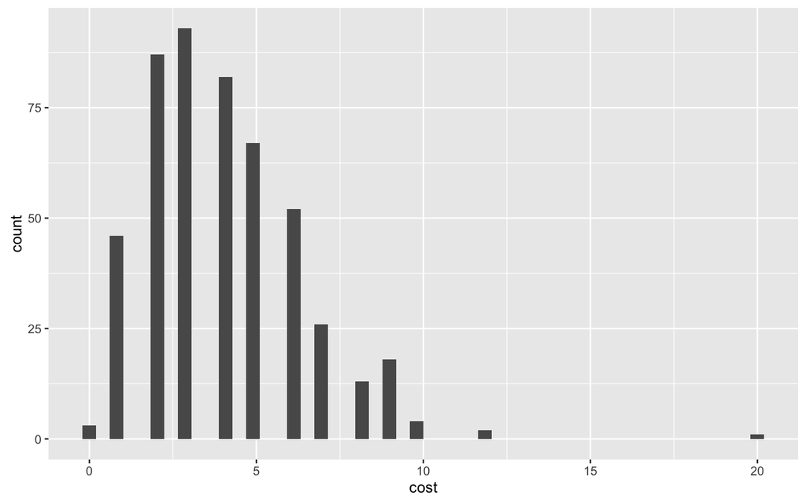

```r
library(ggplot2)
load("minions_text.RData")
## cost vs attack+health:
minions_text %>% ggplot(aes(cost)) + stat_bin(aes(y = ..count..), bins = 50 , position='dodge')
```

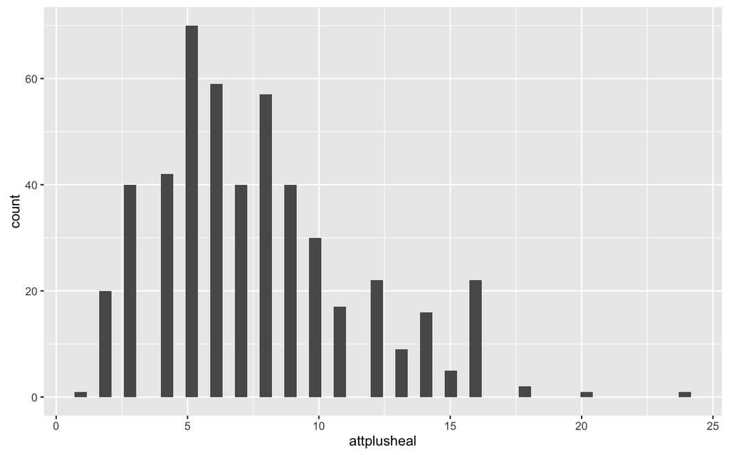

```r
minions_text %>% mutate(attplusheal = attack+health) %>% ggplot(aes(attplusheal)) + stat_bin(aes(y = ..count..), bins = 50 , position='dodge')
```

From the above plots, we can found similar distributions between the cost and the sum of attach and health, where the distributions are right-skewed. Also, there seems to be some outliers that are very different from other cards.

```r
minions_text %>%
  filter(cost > 10) %>%
  select(name, cost, attack, health, mechanics, playerClass)
```

```
## Source: local data frame [3 x 6]
##
##              name  cost attack health mechanics playerClass
##            (fctr) (int)  (int)  (int)     (chr)       (chr)
## 1  Mountain Giant    12      8      8    Normal         All
## 2    Molten Giant    20      8      8    Normal         All
## 3 Clockwork Giant    12      8      8    Normal         All
```

It might be a good idea to filter out these cards.

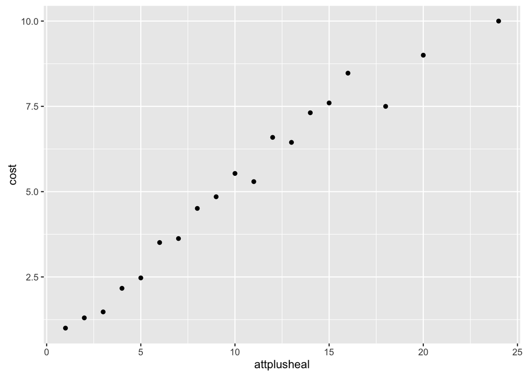

```r
minions_text = minions_text %>% filter(cost <= 10)

## cost vs attack+health:
minions_text %>% mutate(attplusheal = attack+health) %>%
  group_by(attplusheal) %>%
  summarize(cost = mean(cost)) %>%
  ggplot(aes(attplusheal, cost)) + geom_point()
```

We can see from the above graph that higher attplusheal value (attack+health) is associated with higher mean cost.

In Hearthstone, the cost of cards is usually categorized into 0 ~ 6 and 7+. Here, we wrangled the card costs into these 8 categories and also separate them by cardSet:

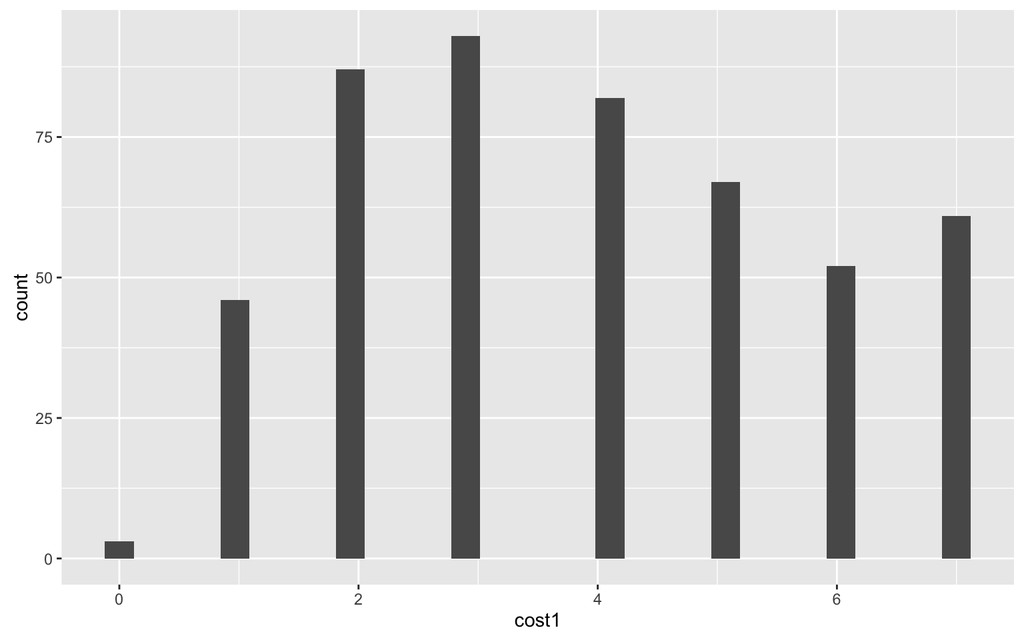

```r
## All:
minions_text = minions_text %>%
  mutate(cost1 = ifelse(cost >= 7, 7, cost)) %>%
  mutate(attplusheal = attack+health)
minions_text %>% ggplot(aes(cost1)) + geom_histogram()
```

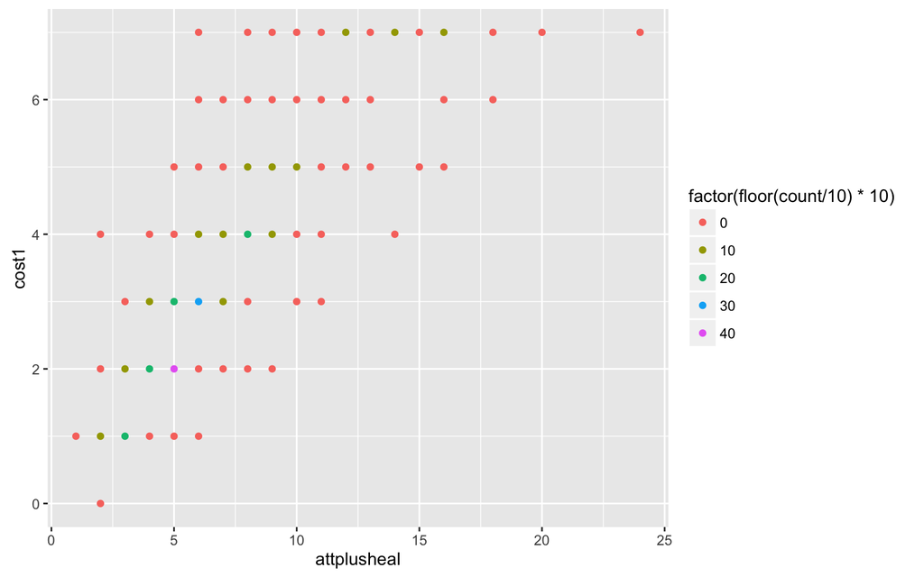

```r
minions_text %>%
  group_by(cost1, attplusheal) %>% summarize(count = n()) %>%
  ggplot(aes(attplusheal, cost1, col = factor(floor(count/10)*10))) + geom_point()
```

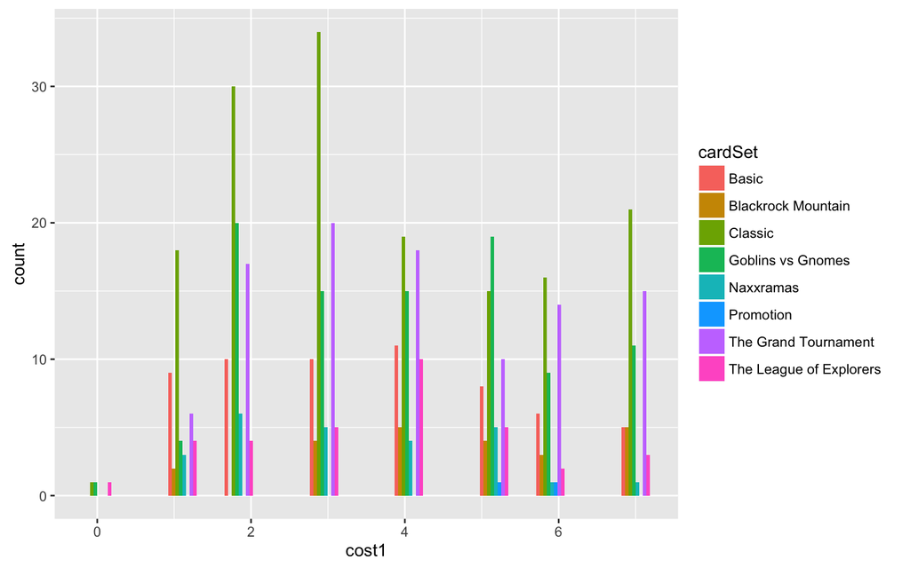

```r
## by cardSet:
minions_text %>% ggplot(aes(cost1, group = cardSet, fill = cardSet)) + stat_bin(aes(y = ..count..), bins = 20 , position='dodge')
```

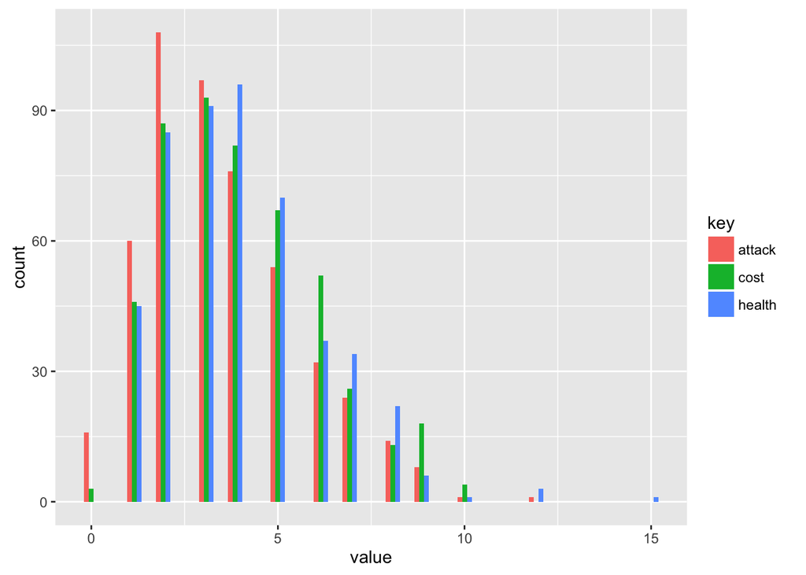

```r
## by attack, cost, health:
minions_bars = minions_text %>% gather(key, value, cost, attack, health)
minions_bars %>% ggplot(aes(value, group = key, fill = key)) + stat_bin(aes(y = ..count..), bins = 40, position='dodge')
```

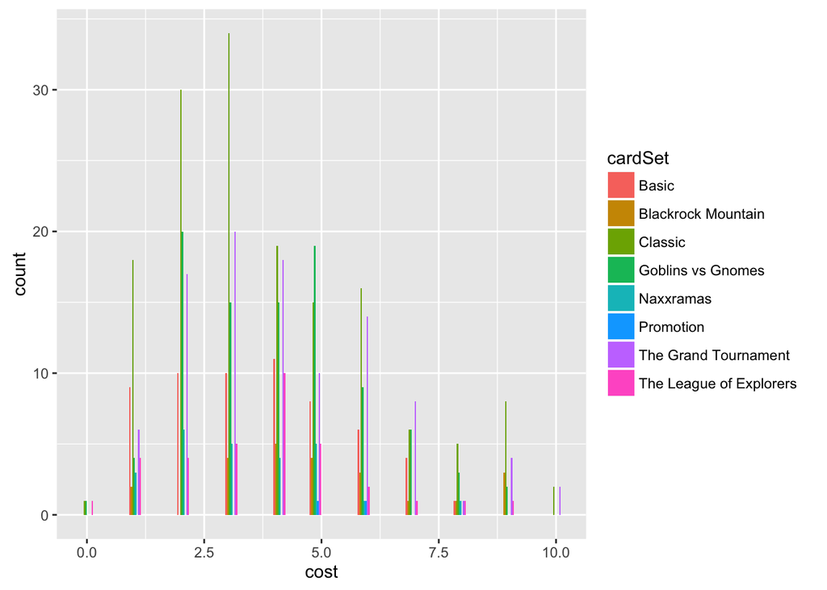

```r
## by cardSet:
## Cost:
minions_text %>% ggplot(aes(cost, group = cardSet, fill = cardSet)) + stat_bin(aes(y = ..count..), bins = 40 , position='dodge')
```

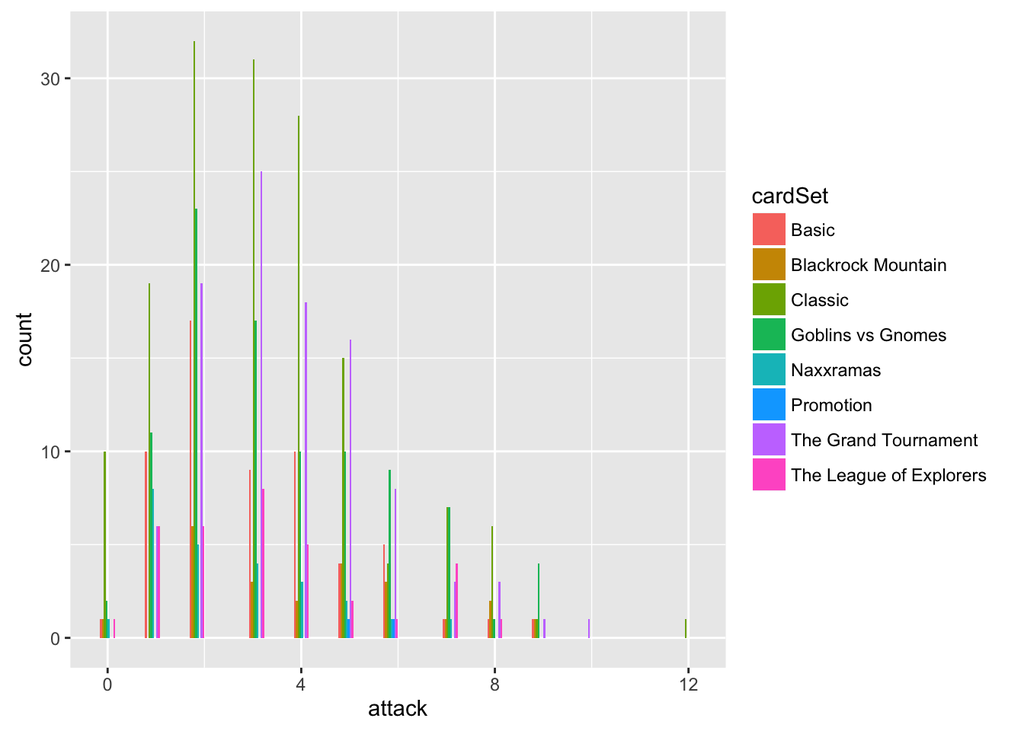

```r
## Attack:
minions_text %>% ggplot(aes(attack, group = cardSet, fill = cardSet)) + stat_bin(aes(y = ..count..), bins = 40 , position='dodge')
```

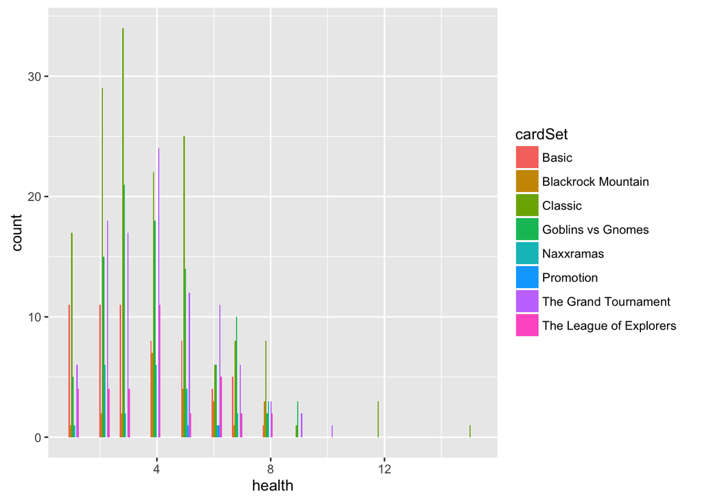

```r
## Health:
minions_text %>% ggplot(aes(health, group = cardSet, fill = cardSet)) + stat_bin(aes(y = ..count..), bins = 40 , position='dodge')
```

Since the outcome variable (Y) in our analysis is the **costs** of cards, which are normally integer from 0 to 7+ (all values greater than 7 are considered in the group of 7+), we adopted a model that consider ordinal polytomous outcome – cumulative logits model. Since the features’ effects (attack, cost, special abilities, etc.) should be the similar in cards with different costs, we also assumed proportional odds of these features across different cost groups. And we ended up with 7 outcome groups (cost value: 1 to 7+), we excluded cards that cost 0 mana since 1) they are usually cards that do not cost players to play and 2) the nature of these 0 cost cards are quite different from normal minion cards. In general, the cumulative logits model is in format shown below, where X is the covariate matrix, and $\beta$ is the coefficient matrix:

$$\mbox{logit(Pr}{(Y \leq k | X_i = x_i))} = \beta_{k0} + \sum \beta_{ki}*x_i$$

Using this cumulative logits model, we are able to estimate the probability of a card being classified in each cost group (p1 to p7), and then by conditioning on the features of a card, we are able to assign a value of that card with the maximum probability among p1 to p7 (the most likely cost of a card based on its features).

Since one of our assumption that the cost of a card is proportional to the damage it can lead to, we first considered a univariate model which include **attack** as the only covariate:

```r
## X: attack
## Y: cost

library(VGAM)
minions_text1 = minions_text %>%
  filter(cost != 0) %>%
  arrange(cost) %>%
  mutate(Y1 = ifelse(cost == 1, 1, 0)) %>%
  mutate(Y2 = ifelse(cost == 2, 1, 0)) %>%
  mutate(Y3 = ifelse(cost == 3, 1, 0)) %>%
  mutate(Y4 = ifelse(cost == 4, 1, 0)) %>%
  mutate(Y5 = ifelse(cost == 5, 1, 0)) %>%
  mutate(Y6 = ifelse(cost == 6, 1, 0)) %>%
  mutate(Y7 = ifelse(cost >= 7, 1, 0))

set.seed(1001)
n_test <- round(nrow(minions_text1) / 10)
test_indices <- sample(1:nrow(minions_text1), n_test, replace=FALSE)
test <- minions_text1[test_indices,]
train <- minions_text1[-test_indices,]

fitCL = vglm(cbind(Y1, Y2, Y3, Y4, Y5, Y6, Y7) ~ attack, cumulative(parallel = T, reverse = F), data = train)
summary(fitCL)
```

```
##
## Call:
## vglm(formula = cbind(Y1, Y2, Y3, Y4, Y5, Y6, Y7) ~ attack, family = cumulative(parallel = T,
##     reverse = F), data = train)
##
## Pearson residuals:
##                    Min       1Q   Median       3Q   Max
## logit(P[Y<=1])  -1.370 -0.26997 -0.09486 -0.02939 4.399
## logit(P[Y<=2])  -3.128 -0.32589 -0.10654  0.30848 3.555
## logit(P[Y<=3])  -5.917 -0.34645 -0.06208  0.32175 3.348
## logit(P[Y<=4]) -11.652 -0.22409  0.11536  0.30653 5.062
## logit(P[Y<=5])  -7.146  0.03019  0.09356  0.20058 4.783
## logit(P[Y<=6])  -7.154  0.02935  0.07494  0.14388 4.186
##
## Coefficients:
##               Estimate Std. Error z value Pr(>|z|)
## (Intercept):1  0.28290    0.21959   1.288    0.198
## (Intercept):2  1.98335    0.20889   9.495   <2e-16 ***
## (Intercept):3  3.30444    0.23652  13.971   <2e-16 ***
## (Intercept):4  4.63750    0.28178  16.458   <2e-16 ***
## (Intercept):5  5.88274    0.33389  17.619   <2e-16 ***
## (Intercept):6  7.24321    0.39832  18.185   <2e-16 ***
## attack        -1.09040    0.06647 -16.403   <2e-16 ***
## ---
## Signif. codes:  0 '***' 0.001 '**' 0.01 '*' 0.05 '.' 0.1 ' ' 1
##
## Number of linear predictors:  6
##
## Dispersion Parameter for cumulative family:   1
##
## Residual deviance: 1302.269 on 2627 degrees of freedom
##
## Log-likelihood: -651.1343 on 2627 degrees of freedom
##
## Number of iterations: 6
##
## Exponentiated coefficients:
##    attack
## 0.3360813
```

```r
for(i in 1: 6){
  assign(paste("coef",i, sep = ""), as.data.frame((coef(fitCL, matrix = T)[,i])))
}


test1 = test %>% mutate(p1 = as.numeric(exp(coef1[1,]+coef1[2,]*attack)/(1+exp(coef1[1,]+coef1[2,]*attack)))) %>%
  mutate(p2 = as.numeric(exp(coef2[1,]+coef2[2,]*attack)/(1+exp(coef2[1,]+coef2[2,]*attack))) - p1) %>%
  mutate(p3 = as.numeric(exp(coef3[1,]+coef3[2,]*attack)/(1+exp(coef3[1,]+coef3[2,]*attack))) - p1 - p2) %>%
  mutate(p4 = as.numeric(exp(coef4[1,]+coef4[2,]*attack)/(1+exp(coef4[1,]+coef4[2,]*attack))) - p1 - p2 - p3) %>%
  mutate(p5 = as.numeric(exp(coef5[1,]+coef5[2,]*attack)/(1+exp(coef5[1,]+coef5[2,]*attack))) - p1 - p2 - p3 - p4) %>%
  mutate(p6 = as.numeric(exp(coef6[1,]+coef6[2,]*attack)/(1+exp(coef6[1,]+coef6[2,]*attack))) - p1 - p2 - p3 - p4 - p5) %>% mutate(p7 = 1 - p1 - p2 - p3 - p4 - p5 - p6) %>%
  mutate(value = 7) %>%
  group_by(cardId) %>%
  summarize(value = ifelse(max(p1,p2,p3,p4,p5,p6,p7) == p1, 1, value),
              value = ifelse(max(p1,p2,p3,p4,p5,p6,p7) == p2, 2, value),
              value = ifelse(max(p1,p2,p3,p4,p5,p6,p7) == p3, 3, value),
              value = ifelse(max(p1,p2,p3,p4,p5,p6,p7) == p4, 4, value),
              value = ifelse(max(p1,p2,p3,p4,p5,p6,p7) == p5, 5, value),
              value = ifelse(max(p1,p2,p3,p4,p5,p6,p7) == p6, 6, value))

test1 = test %>% left_join(test1, by = "cardId")
RMSE <- function(true_ratings, predicted_ratings){
    sqrt(mean((true_ratings - predicted_ratings)^2))
}
model1 = RMSE(test1$cost1, test1$value)
rmse_results = data_frame(method = "X: attack", RMSE = model1)
```

Since the cost of a card can also be influenced by the time it can survive on the stage, we also included some potential effect of health by summing up both attack and health (**attack+health** ) as a univariate:

```r
## X: attplusheal
## Y: cost

library(VGAM)

fitCL = vglm(cbind(Y1, Y2, Y3, Y4, Y5, Y6, Y7) ~ attplusheal, cumulative(parallel = T, reverse = F), data = train)
summary(fitCL)
```

```
##
## Call:
## vglm(formula = cbind(Y1, Y2, Y3, Y4, Y5, Y6, Y7) ~ attplusheal,
##     family = cumulative(parallel = T, reverse = F), data = train)
##
## Pearson residuals:
##                    Min       1Q    Median       3Q    Max
## logit(P[Y<=1])  -1.515 -0.15964 -0.048923 -0.01063  3.275
## logit(P[Y<=2])  -2.710 -0.21895 -0.049533  0.15689  8.737
## logit(P[Y<=3]) -11.482 -0.20851 -0.009906  0.25237  9.475
## logit(P[Y<=4])  -6.589 -0.10219  0.064701  0.18587 16.730
## logit(P[Y<=5])  -9.118  0.01002  0.044353  0.14831 19.690
## logit(P[Y<=6]) -25.520  0.01022  0.028066  0.09161 17.816
##
## Coefficients:
##               Estimate Std. Error z value Pr(>|z|)
## (Intercept):1  2.66587    0.29944   8.903   <2e-16 ***
## (Intercept):2  4.86325    0.32714  14.866   <2e-16 ***
## (Intercept):3  6.76313    0.39193  17.256   <2e-16 ***
## (Intercept):4  8.65585    0.47204  18.337   <2e-16 ***
## (Intercept):5 10.38817    0.55145  18.838   <2e-16 ***
## (Intercept):6 12.55323    0.66926  18.757   <2e-16 ***
## attplusheal   -1.01103    0.05517 -18.324   <2e-16 ***
## ---
## Signif. codes:  0 '***' 0.001 '**' 0.01 '*' 0.05 '.' 0.1 ' ' 1
##
## Number of linear predictors:  6
##
## Dispersion Parameter for cumulative family:   1
##
## Residual deviance: 1059.609 on 2627 degrees of freedom
##
## Log-likelihood: -529.8043 on 2627 degrees of freedom
##
## Number of iterations: 7
##
## Exponentiated coefficients:
## attplusheal
##   0.3638422
```

```r
for(i in 1: 6){
  assign(paste("coef",i, sep = ""), as.data.frame((coef(fitCL, matrix = T)[,i])))
}
test2 = test %>% mutate(p1 = as.numeric(exp(coef1[1,]+coef1[2,]*attack)/(1+exp(coef1[1,]+coef1[2,]*attack)))) %>%
  mutate(p2 = as.numeric(exp(coef2[1,]+coef2[2,]*attack)/(1+exp(coef2[1,]+coef2[2,]*attack))) - p1) %>%
  mutate(p3 = as.numeric(exp(coef3[1,]+coef3[2,]*attack)/(1+exp(coef3[1,]+coef3[2,]*attack))) - p1 - p2) %>%
  mutate(p4 = as.numeric(exp(coef4[1,]+coef4[2,]*attack)/(1+exp(coef4[1,]+coef4[2,]*attack))) - p1 - p2 - p3) %>%
  mutate(p5 = as.numeric(exp(coef5[1,]+coef5[2,]*attack)/(1+exp(coef5[1,]+coef5[2,]*attack))) - p1 - p2 - p3 - p4) %>%
  mutate(p6 = as.numeric(exp(coef6[1,]+coef6[2,]*attack)/(1+exp(coef6[1,]+coef6[2,]*attack))) - p1 - p2 - p3 - p4 - p5) %>%
  mutate(p7 = 1 - p1 - p2 - p3 - p4 - p5 - p6) %>%
  mutate(value = 7) %>%
  group_by(cardId) %>%
  summarize(value = ifelse(max(p1,p2,p3,p4,p5,p6,p7) == p1, 1, value),
              value = ifelse(max(p1,p2,p3,p4,p5,p6,p7) == p2, 2, value),
              value = ifelse(max(p1,p2,p3,p4,p5,p6,p7) == p3, 3, value),
              value = ifelse(max(p1,p2,p3,p4,p5,p6,p7) == p4, 4, value),
              value = ifelse(max(p1,p2,p3,p4,p5,p6,p7) == p5, 5, value),
              value = ifelse(max(p1,p2,p3,p4,p5,p6,p7) == p6, 6, value))

test2 = test %>% left_join(test2, by = "cardId")
model2 = RMSE(test2$cost1, test2$value)
rmse_results =  bind_rows(rmse_results, data_frame(method = "X: attplusheal", RMSE = model2))
```

```r
## X: attack, health
## Y: cost

library(VGAM)
fitCL = vglm(cbind(Y1, Y2, Y3, Y4, Y5, Y6, Y7) ~ health + attack, cumulative(parallel = T, reverse = F), data = train)
summary(fitCL)
```

```
##
## Call:
## vglm(formula = cbind(Y1, Y2, Y3, Y4, Y5, Y6, Y7) ~ health + attack,
##     family = cumulative(parallel = T, reverse = F), data = train)
##
## Pearson residuals:
##                    Min       1Q    Median       3Q    Max
## logit(P[Y<=1])  -1.538 -0.16101 -0.048661 -0.01031  3.323
## logit(P[Y<=2])  -2.779 -0.21961 -0.050148  0.15741  8.705
## logit(P[Y<=3]) -11.421 -0.20883 -0.009917  0.25179  9.272
## logit(P[Y<=4])  -6.486 -0.10164  0.062692  0.18677 16.866
## logit(P[Y<=5])  -8.910  0.01003  0.044915  0.14851 19.803
## logit(P[Y<=6]) -24.968  0.01005  0.028135  0.09174 17.914
##
## Coefficients:
##               Estimate Std. Error z value Pr(>|z|)
## (Intercept):1  2.65968    0.29992   8.868   <2e-16 ***
## (Intercept):2  4.85611    0.32768  14.819   <2e-16 ***
## (Intercept):3  6.75392    0.39232  17.215   <2e-16 ***
## (Intercept):4  8.64783    0.47235  18.308   <2e-16 ***
## (Intercept):5 10.38520    0.55182  18.820   <2e-16 ***
## (Intercept):6 12.55254    0.66968  18.744   <2e-16 ***
## health        -0.99182    0.07251 -13.679   <2e-16 ***
## attack        -1.03142    0.07461 -13.825   <2e-16 ***
## ---
## Signif. codes:  0 '***' 0.001 '**' 0.01 '*' 0.05 '.' 0.1 ' ' 1
##
## Number of linear predictors:  6
##
## Dispersion Parameter for cumulative family:   1
##
## Residual deviance: 1059.45 on 2626 degrees of freedom
##
## Log-likelihood: -529.7248 on 2626 degrees of freedom
##
## Number of iterations: 7
##
## Exponentiated coefficients:
##    health    attack
## 0.3708994 0.3565014
```

```r
for(i in 1: 6){
  assign(paste("coef",i, sep = ""), as.data.frame((coef(fitCL, matrix = T)[,i])))
}
test3 = test %>% mutate(p1 = as.numeric(exp(coef1[1,]+coef1[2,]*health+coef1[3,]*attack)/(1+exp(coef1[1,]+coef1[2,]*health+coef1[3,]*attack)))) %>%
  mutate(p2 = as.numeric(exp(coef2[1,]+coef2[2,]*health+coef2[3,]*attack)/(1+exp(coef2[1,]+coef2[2,]*health+coef2[3,]*attack))) - p1) %>%
  mutate(p3 = as.numeric(exp(coef3[1,]+coef3[2,]*health+coef3[3,]*attack)/(1+exp(coef3[1,]+coef3[2,]*health+coef3[3,]*attack))) - p1 - p2) %>%
  mutate(p4 = as.numeric(exp(coef4[1,]+coef4[2,]*health+coef4[3,]*attack)/(1+exp(coef4[1,]+coef4[2,]*health+coef4[3,]*attack))) - p1 - p2 - p3) %>%
  mutate(p5 = as.numeric(exp(coef5[1,]+coef5[2,]*health+coef5[3,]*attack)/(1+exp(coef5[1,]+coef5[2,]*health+coef5[3,]*attack))) - p1 - p2 - p3 - p4) %>%
  mutate(p6 = as.numeric(exp(coef6[1,]+coef6[2,]*health+coef6[3,]*attack)/(1+exp(coef6[1,]+coef6[2,]*health+coef6[3,]*attack))) - p1 - p2 - p3 - p4 - p5) %>% mutate(p7 = 1 - p1 - p2 - p3 - p4 - p5 - p6) %>%
  mutate(value = 7) %>%
  group_by(cardId) %>%
  summarize(value = ifelse(max(p1,p2,p3,p4,p5,p6,p7) == p1, 1, value),
              value = ifelse(max(p1,p2,p3,p4,p5,p6,p7) == p2, 2, value),
              value = ifelse(max(p1,p2,p3,p4,p5,p6,p7) == p3, 3, value),
              value = ifelse(max(p1,p2,p3,p4,p5,p6,p7) == p4, 4, value),
              value = ifelse(max(p1,p2,p3,p4,p5,p6,p7) == p5, 5, value),
              value = ifelse(max(p1,p2,p3,p4,p5,p6,p7) == p6, 6, value))

test3 = test %>% left_join(test3, by = "cardId")
model3 = RMSE(test3$cost1, test3$value)
rmse_results = bind_rows(rmse_results,data_frame(method="X: attack, health",
                                     RMSE = model3))
rmse_results
```

```
## Source: local data frame [3 x 2]
##
##              method      RMSE
##               (chr)     (dbl)
## 1         X: attack 1.0973065
## 2    X: attplusheal 2.1712406
## 3 X: attack, health 0.8451543
```

We then considered a model which include some feature of the cards, and **Charge** was the only feature that was significant:

```r
## X: attack, health, charge
## Y: cost

fitCL = vglm(cbind(Y1, Y2, Y3, Y4, Y5, Y6, Y7) ~ health + attack + Charge, cumulative(parallel = T, reverse = F), data = train)
summary(fitCL)
```

```
##
## Call:
## vglm(formula = cbind(Y1, Y2, Y3, Y4, Y5, Y6, Y7) ~ health + attack +
##     Charge, family = cumulative(parallel = T, reverse = F), data = train)
##
## Pearson residuals:
##                    Min        1Q    Median       3Q    Max
## logit(P[Y<=1])  -1.604 -0.152431 -0.048501 -0.01011  3.216
## logit(P[Y<=2])  -2.901 -0.221423 -0.049173  0.14829  8.759
## logit(P[Y<=3]) -12.467 -0.208581 -0.009409  0.24298  9.508
## logit(P[Y<=4])  -7.018 -0.101494  0.060353  0.17748 17.257
## logit(P[Y<=5])  -4.764  0.009027  0.041638  0.15192 20.656
## logit(P[Y<=6]) -27.476  0.009199  0.026035  0.08691 18.771
##
## Coefficients:
##               Estimate Std. Error z value Pr(>|z|)
## (Intercept):1  2.82331    0.30711   9.193  < 2e-16 ***
## (Intercept):2  5.05096    0.33660  15.006  < 2e-16 ***
## (Intercept):3  6.97800    0.40440  17.255  < 2e-16 ***
## (Intercept):4  8.90530    0.48668  18.298  < 2e-16 ***
## (Intercept):5 10.65185    0.56474  18.862  < 2e-16 ***
## (Intercept):6 12.85167    0.68394  18.791  < 2e-16 ***
## health        -1.02586    0.07421 -13.824  < 2e-16 ***
## attack        -1.04143    0.07510 -13.867  < 2e-16 ***
## Charge        -1.40805    0.42670  -3.300 0.000967 ***
## ---
## Signif. codes:  0 '***' 0.001 '**' 0.01 '*' 0.05 '.' 0.1 ' ' 1
##
## Number of linear predictors:  6
##
## Dispersion Parameter for cumulative family:   1
##
## Residual deviance: 1048.811 on 2625 degrees of freedom
##
## Log-likelihood: -524.4057 on 2625 degrees of freedom
##
## Number of iterations: 7
##
## Exponentiated coefficients:
##    health    attack    Charge
## 0.3584867 0.3529491 0.2446196
```

```r
for(i in 1: 6){
  assign(paste("coef",i, sep = ""), as.data.frame((coef(fitCL, matrix = T)[,i])))
}
test3 = test %>% mutate(p1 = as.numeric(exp(coef1[1,]+coef1[2,]*health+coef1[3,]*attack+coef1[4,]*Charge)/(1+exp(coef1[1,]+coef1[2,]*health+coef1[3,]*attack+coef1[4,]*Charge)))) %>%
  mutate(p2 = as.numeric(exp(coef2[1,]+coef2[2,]*health+coef2[3,]*attack+coef1[4,]*Charge)/(1+exp(coef2[1,]+coef2[2,]*health+coef2[3,]*attack+coef1[4,]*Charge))) - p1) %>%
  mutate(p3 = as.numeric(exp(coef3[1,]+coef3[2,]*health+coef3[3,]*attack+coef1[4,]*Charge)/(1+exp(coef3[1,]+coef3[2,]*health+coef3[3,]*attack+coef1[4,]*Charge))) - p1 - p2) %>%
  mutate(p4 = as.numeric(exp(coef4[1,]+coef4[2,]*health+coef4[3,]*attack+coef1[4,]*Charge)/(1+exp(coef4[1,]+coef4[2,]*health+coef4[3,]*attack+coef1[4,]*Charge))) - p1 - p2 - p3) %>%
  mutate(p5 = as.numeric(exp(coef5[1,]+coef5[2,]*health+coef5[3,]*attack+coef1[4,]*Charge)/(1+exp(coef5[1,]+coef5[2,]*health+coef5[3,]*attack+coef1[4,]*Charge))) - p1 - p2 - p3 - p4) %>%
  mutate(p6 = as.numeric(exp(coef6[1,]+coef6[2,]*health+coef6[3,]*attack+coef1[4,]*Charge)/(1+exp(coef6[1,]+coef6[2,]*health+coef6[3,]*attack+coef1[4,]*Charge))) - p1 - p2 - p3 - p4 - p5) %>% mutate(p7 = 1 - p1 - p2 - p3 - p4 - p5 - p6) %>%
  mutate(value = 7) %>%
  group_by(cardId) %>%
  summarize(value = ifelse(max(p1,p2,p3,p4,p5,p6,p7) == p1, 1, value),
              value = ifelse(max(p1,p2,p3,p4,p5,p6,p7) == p2, 2, value),
              value = ifelse(max(p1,p2,p3,p4,p5,p6,p7) == p3, 3, value),
              value = ifelse(max(p1,p2,p3,p4,p5,p6,p7) == p4, 4, value),
              value = ifelse(max(p1,p2,p3,p4,p5,p6,p7) == p5, 5, value),
              value = ifelse(max(p1,p2,p3,p4,p5,p6,p7) == p6, 6, value))

test3 = test %>%
  select(cost, cost1, attack, health, cardId, playerClass, mechanics) %>%
  left_join(test3, by = "cardId")
model3 = RMSE(test3$cost1, test3$value)
rmse_results = bind_rows(rmse_results,data_frame(method="X: attack, health, charge",
                                     RMSE = model3))
rmse_results
```

```
## Source: local data frame [4 x 2]
##
##                      method      RMSE
##                       (chr)     (dbl)
## 1                 X: attack 1.0973065
## 2            X: attplusheal 2.1712406
## 3         X: attack, health 0.8451543
## 4 X: attack, health, charge 0.8806306
```

```r
## X: attack, health, charge, divine shield, taunt
## Y: cost

fitCL = vglm(cbind(Y1, Y2, Y3, Y4, Y5, Y6, Y7) ~ health + attack + Charge + Divine_Shield + Taunt, cumulative(parallel = T, reverse = F), data = train)
summary(fitCL)
```

```
##
## Call:
## vglm(formula = cbind(Y1, Y2, Y3, Y4, Y5, Y6, Y7) ~ health + attack +
##     Charge + Divine_Shield + Taunt, family = cumulative(parallel = T,
##     reverse = F), data = train)
##
## Pearson residuals:
##                    Min        1Q    Median        3Q    Max
## logit(P[Y<=1])  -1.603 -0.151596 -0.048023 -0.009999  3.209
## logit(P[Y<=2])  -2.906 -0.220815 -0.048349  0.170010  8.847
## logit(P[Y<=3]) -12.693 -0.208188 -0.008328  0.242129  9.736
## logit(P[Y<=4])  -7.099 -0.100285  0.059698  0.176785 17.643
## logit(P[Y<=5])  -4.804  0.008864  0.041094  0.151810 21.167
## logit(P[Y<=6]) -28.447  0.009007  0.025472  0.085272 18.992
##
## Coefficients:
##               Estimate Std. Error z value Pr(>|z|)
## (Intercept):1  2.85375    0.31092   9.178  < 2e-16 ***
## (Intercept):2  5.09795    0.34100  14.950  < 2e-16 ***
## (Intercept):3  7.02789    0.40825  17.215  < 2e-16 ***
## (Intercept):4  8.95616    0.49007  18.275  < 2e-16 ***
## (Intercept):5 10.71043    0.56854  18.839  < 2e-16 ***
## (Intercept):6 12.94628    0.69145  18.723  < 2e-16 ***
## health        -1.04033    0.07494 -13.881  < 2e-16 ***
## attack        -1.04055    0.07533 -13.812  < 2e-16 ***
## Charge        -1.42043    0.42805  -3.318 0.000905 ***
## Divine_Shield -1.22650    0.77137  -1.590 0.111829
## Taunt          0.32225    0.38909   0.828 0.407555
## ---
## Signif. codes:  0 '***' 0.001 '**' 0.01 '*' 0.05 '.' 0.1 ' ' 1
##
## Number of linear predictors:  6
##
## Dispersion Parameter for cumulative family:   1
##
## Residual deviance: 1045.159 on 2623 degrees of freedom
##
## Log-likelihood: -522.5793 on 2623 degrees of freedom
##
## Number of iterations: 7
##
## Exponentiated coefficients:
##        health        attack        Charge Divine_Shield         Taunt
##     0.3533373     0.3532588     0.2416097     0.2933172     1.3802276
```

```r
for(i in 1: 6){
  assign(paste("coef",i, sep = ""), as.data.frame((coef(fitCL, matrix = T)[,i])))
}
test3 = test %>% mutate(p1 = as.numeric(exp(coef1[1,]+coef1[2,]*health+coef1[3,]*attack+coef1[4,]*Charge+coef1[5,]*Divine_Shield+coef1[6,]*Taunt)/(1+exp(coef1[1,]+coef1[2,]*health+coef1[3,]*attack+coef1[4,]*Charge+coef1[5,]*Divine_Shield+coef1[6,]*Taunt)))) %>%
  mutate(p2 = as.numeric(exp(coef2[1,]+coef2[2,]*health+coef2[3,]*attack+coef1[4,]*Charge+coef1[5,]*Divine_Shield+coef1[6,]*Taunt)/(1+exp(coef2[1,]+coef2[2,]*health+coef2[3,]*attack+coef1[4,]*Charge+coef1[5,]*Divine_Shield+coef1[6,]*Taunt))) - p1) %>%
  mutate(p3 = as.numeric(exp(coef3[1,]+coef3[2,]*health+coef3[3,]*attack+coef1[4,]*Charge+coef1[5,]*Divine_Shield+coef1[6,]*Taunt)/(1+exp(coef3[1,]+coef3[2,]*health+coef3[3,]*attack+coef1[4,]*Charge+coef1[5,]*Divine_Shield+coef1[6,]*Taunt))) - p1 - p2) %>%
  mutate(p4 = as.numeric(exp(coef4[1,]+coef4[2,]*health+coef4[3,]*attack+coef1[4,]*Charge+coef1[5,]*Divine_Shield+coef1[6,]*Taunt)/(1+exp(coef4[1,]+coef4[2,]*health+coef4[3,]*attack+coef1[4,]*Charge+coef1[5,]*Divine_Shield+coef1[6,]*Taunt))) - p1 - p2 - p3) %>%
  mutate(p5 = as.numeric(exp(coef5[1,]+coef5[2,]*health+coef5[3,]*attack+coef1[4,]*Charge+coef1[5,]*Divine_Shield+coef1[6,]*Taunt)/(1+exp(coef5[1,]+coef5[2,]*health+coef5[3,]*attack+coef1[4,]*Charge+coef1[5,]*Divine_Shield+coef1[6,]*Taunt))) - p1 - p2 - p3 - p4) %>%
  mutate(p6 = as.numeric(exp(coef6[1,]+coef6[2,]*health+coef6[3,]*attack+coef1[4,]*Charge+coef1[5,]*Divine_Shield+coef1[6,]*Taunt)/(1+exp(coef6[1,]+coef6[2,]*health+coef6[3,]*attack+coef1[4,]*Charge+coef1[5,]*Divine_Shield+coef1[6,]*Taunt))) - p1 - p2 - p3 - p4 - p5) %>% mutate(p7 = 1 - p1 - p2 - p3 - p4 - p5 - p6) %>%
  mutate(value = 7) %>%
  group_by(cardId) %>%
  summarize(value = ifelse(max(p1,p2,p3,p4,p5,p6,p7) == p1, 1, value),
              value = ifelse(max(p1,p2,p3,p4,p5,p6,p7) == p2, 2, value),
              value = ifelse(max(p1,p2,p3,p4,p5,p6,p7) == p3, 3, value),
              value = ifelse(max(p1,p2,p3,p4,p5,p6,p7) == p4, 4, value),
              value = ifelse(max(p1,p2,p3,p4,p5,p6,p7) == p5, 5, value),
              value = ifelse(max(p1,p2,p3,p4,p5,p6,p7) == p6, 6, value))

test3 = test %>%
  select(cost, cost1, attack, health, mechanics, name, cardId) %>%
  left_join(test3, by = "cardId")
model3 = RMSE(test3$cost1, test3$value)
rmse_results = bind_rows(rmse_results,data_frame(method="X: attack, health, charge, divine shield, taunt",
                                     RMSE = model3))
rmse_results
```

```
## Source: local data frame [5 x 2]
##
##                                            method      RMSE
##                                             (chr)     (dbl)
## 1                                       X: attack 1.0973065
## 2                                  X: attplusheal 2.1712406
## 3                               X: attack, health 0.8451543
## 4                       X: attack, health, charge 0.8806306
## 5 X: attack, health, charge, divine shield, taunt 0.8806306
```

```r
## X: attack, health, charge, divine shield, taunt in warlock
## Y: cost

train_warlock = train %>% filter(playerClass == "All" | playerClass == "Warlock")
fitCL = vglm(cbind(Y1, Y2, Y3, Y4, Y5, Y6, Y7) ~ health + attack + Charge + Divine_Shield + Taunt, cumulative(parallel = T, reverse = F), data = train_warlock)
summary(fitCL)
```

```
##
## Call:
## vglm(formula = cbind(Y1, Y2, Y3, Y4, Y5, Y6, Y7) ~ health + attack +
##     Charge + Divine_Shield + Taunt, family = cumulative(parallel = T,
##     reverse = F), data = train_warlock)
##
## Pearson residuals:
##                    Min       1Q    Median        3Q    Max
## logit(P[Y<=1])  -1.591 -0.19190 -0.051266 -0.009982  3.219
## logit(P[Y<=2])  -2.792 -0.22210 -0.051695  0.200438  8.530
## logit(P[Y<=3]) -11.822 -0.21232 -0.006281  0.248470  8.626
## logit(P[Y<=4])  -4.180 -0.09940  0.060560  0.190220 16.998
## logit(P[Y<=5])  -4.388  0.01056  0.046722  0.163132 19.633
## logit(P[Y<=6])  -2.222  0.00846  0.024308  0.082523 13.735
##
## Coefficients:
##               Estimate Std. Error z value Pr(>|z|)
## (Intercept):1  2.69361    0.36868   7.306 2.75e-13 ***
## (Intercept):2  4.83357    0.40207  12.022  < 2e-16 ***
## (Intercept):3  6.78692    0.48587  13.969  < 2e-16 ***
## (Intercept):4  8.55470    0.57672  14.833  < 2e-16 ***
## (Intercept):5 10.29323    0.66879  15.391  < 2e-16 ***
## (Intercept):6 12.91476    0.84904  15.211  < 2e-16 ***
## health        -0.97736    0.08778 -11.135  < 2e-16 ***
## attack        -1.03184    0.09037 -11.418  < 2e-16 ***
## Charge        -1.30782    0.54051  -2.420   0.0155 *
## Divine_Shield -1.25851    0.91196  -1.380   0.1676
## Taunt          0.16517    0.41567   0.397   0.6911
## ---
## Signif. codes:  0 '***' 0.001 '**' 0.01 '*' 0.05 '.' 0.1 ' ' 1
##
## Number of linear predictors:  6
##
## Dispersion Parameter for cumulative family:   1
##
## Residual deviance: 703.5597 on 1753 degrees of freedom
##
## Log-likelihood: -351.7799 on 1753 degrees of freedom
##
## Number of iterations: 7
##
## Exponentiated coefficients:
##        health        attack        Charge Divine_Shield         Taunt
##     0.3763042     0.3563509     0.2704087     0.2840778     1.1795917
```

```r
test_warlock = test %>% filter(playerClass == "All" | playerClass == "Warlock")

for(i in 1: 6){
  assign(paste("coef",i, sep = ""), as.data.frame((coef(fitCL, matrix = T)[,i])))
}
test_warlock = test_warlock %>% mutate(p1 = as.numeric(exp(coef1[1,]+coef1[2,]*health+coef1[3,]*attack+coef1[4,]*Charge+coef1[5,]*Divine_Shield+coef1[6,]*Taunt)/(1+exp(coef1[1,]+coef1[2,]*health+coef1[3,]*attack+coef1[4,]*Charge+coef1[5,]*Divine_Shield+coef1[6,]*Taunt)))) %>%
  mutate(p2 = as.numeric(exp(coef2[1,]+coef2[2,]*health+coef2[3,]*attack+coef1[4,]*Charge+coef1[5,]*Divine_Shield+coef1[6,]*Taunt)/(1+exp(coef2[1,]+coef2[2,]*health+coef2[3,]*attack+coef1[4,]*Charge+coef1[5,]*Divine_Shield+coef1[6,]*Taunt))) - p1) %>%
  mutate(p3 = as.numeric(exp(coef3[1,]+coef3[2,]*health+coef3[3,]*attack+coef1[4,]*Charge+coef1[5,]*Divine_Shield+coef1[6,]*Taunt)/(1+exp(coef3[1,]+coef3[2,]*health+coef3[3,]*attack+coef1[4,]*Charge+coef1[5,]*Divine_Shield+coef1[6,]*Taunt))) - p1 - p2) %>%
  mutate(p4 = as.numeric(exp(coef4[1,]+coef4[2,]*health+coef4[3,]*attack+coef1[4,]*Charge+coef1[5,]*Divine_Shield+coef1[6,]*Taunt)/(1+exp(coef4[1,]+coef4[2,]*health+coef4[3,]*attack+coef1[4,]*Charge+coef1[5,]*Divine_Shield+coef1[6,]*Taunt))) - p1 - p2 - p3) %>%
  mutate(p5 = as.numeric(exp(coef5[1,]+coef5[2,]*health+coef5[3,]*attack+coef1[4,]*Charge+coef1[5,]*Divine_Shield+coef1[6,]*Taunt)/(1+exp(coef5[1,]+coef5[2,]*health+coef5[3,]*attack+coef1[4,]*Charge+coef1[5,]*Divine_Shield+coef1[6,]*Taunt))) - p1 - p2 - p3 - p4) %>%
  mutate(p6 = as.numeric(exp(coef6[1,]+coef6[2,]*health+coef6[3,]*attack+coef1[4,]*Charge+coef1[5,]*Divine_Shield+coef1[6,]*Taunt)/(1+exp(coef6[1,]+coef6[2,]*health+coef6[3,]*attack+coef1[4,]*Charge+coef1[5,]*Divine_Shield+coef1[6,]*Taunt))) - p1 - p2 - p3 - p4 - p5) %>% mutate(p7 = 1 - p1 - p2 - p3 - p4 - p5 - p6) %>%
  mutate(value = 7) %>%
  group_by(cardId, cost1, attack, health) %>%
  summarize(value = ifelse(max(p1,p2,p3,p4,p5,p6,p7) == p1, 1, value),
              value = ifelse(max(p1,p2,p3,p4,p5,p6,p7) == p2, 2, value),
              value = ifelse(max(p1,p2,p3,p4,p5,p6,p7) == p3, 3, value),
              value = ifelse(max(p1,p2,p3,p4,p5,p6,p7) == p4, 4, value),
              value = ifelse(max(p1,p2,p3,p4,p5,p6,p7) == p5, 5, value),
              value = ifelse(max(p1,p2,p3,p4,p5,p6,p7) == p6, 6, value))

model3 = RMSE(test_warlock$cost1, test_warlock$value)
rmse_results = bind_rows(rmse_results,data_frame(method="X: attack, health, charge, divine shield, taunt in warlock",
                                     RMSE = model3))
rmse_results
```

```
## Source: local data frame [6 x 2]
##
##                                                       method      RMSE
##                                                        (chr)     (dbl)
## 1                                                  X: attack 1.0973065
## 2                                             X: attplusheal 2.1712406
## 3                                          X: attack, health 0.8451543
## 4                                  X: attack, health, charge 0.8806306
## 5            X: attack, health, charge, divine shield, taunt 0.8806306
## 6 X: attack, health, charge, divine shield, taunt in warlock 0.9393364
```

```r
fitCL = vglm(cbind(Y1, Y2, Y3, Y4, Y5, Y6, Y7) ~ health + attack + Charge + Divine_Shield + Taunt, cumulative(parallel = T, reverse = F), data = minions_text1)
summary(fitCL)
```

```
##
## Call:
## vglm(formula = cbind(Y1, Y2, Y3, Y4, Y5, Y6, Y7) ~ health + attack +
##     Charge + Divine_Shield + Taunt, family = cumulative(parallel = T,
##     reverse = F), data = minions_text1)
##
## Pearson residuals:
##                    Min        1Q    Median        3Q    Max
## logit(P[Y<=1])  -1.595 -0.166733 -0.046307 -0.009202  5.593
## logit(P[Y<=2])  -2.922 -0.219257 -0.047367  0.196809  9.030
## logit(P[Y<=3]) -13.386 -0.207826 -0.005203  0.235558  9.888
## logit(P[Y<=4])  -6.959 -0.096409  0.057904  0.179912 19.107
## logit(P[Y<=5])  -5.325  0.008591  0.040716  0.147200 22.079
## logit(P[Y<=6]) -29.253  0.008756  0.025017  0.083758 20.022
##
## Coefficients:
##               Estimate Std. Error z value Pr(>|z|)
## (Intercept):1  2.87739    0.29498   9.754  < 2e-16 ***
## (Intercept):2  5.17179    0.32551  15.888  < 2e-16 ***
## (Intercept):3  7.14499    0.39177  18.238  < 2e-16 ***
## (Intercept):4  8.98798    0.46589  19.292  < 2e-16 ***
## (Intercept):5 10.81457    0.54491  19.847  < 2e-16 ***
## (Intercept):6 13.06520    0.66349  19.692  < 2e-16 ***
## health        -1.05901    0.07188 -14.734  < 2e-16 ***
## attack        -1.04702    0.07206 -14.530  < 2e-16 ***
## Charge        -1.25559    0.41765  -3.006  0.00264 **
## Divine_Shield -1.24240    0.77257  -1.608  0.10781
## Taunt          0.32869    0.36830   0.892  0.37215
## ---
## Signif. codes:  0 '***' 0.001 '**' 0.01 '*' 0.05 '.' 0.1 ' ' 1
##
## Number of linear predictors:  6
##
## Dispersion Parameter for cumulative family:   1
##
## Residual deviance: 1151.674 on 2917 degrees of freedom
##
## Log-likelihood: -575.8368 on 2917 degrees of freedom
##
## Number of iterations: 7
##
## Exponentiated coefficients:
##        health        attack        Charge Divine_Shield         Taunt
##     0.3467998     0.3509830     0.2849067     0.2886917     1.3891540
```

```r
for(i in 1: 6){
  assign(paste("coef",i, sep = ""), as.data.frame((coef(fitCL, matrix = T)[,i])))
}
final = minions_text %>% mutate(p1 = as.numeric(exp(coef1[1,]+coef1[2,]*health+coef1[3,]*attack+coef1[4,]*Charge+coef1[5,]*Divine_Shield+coef1[6,]*Taunt)/(1+exp(coef1[1,]+coef1[2,]*health+coef1[3,]*attack+coef1[4,]*Charge+coef1[5,]*Divine_Shield+coef1[6,]*Taunt)))) %>%
  mutate(p2 = as.numeric(exp(coef2[1,]+coef2[2,]*health+coef2[3,]*attack+coef1[4,]*Charge+coef1[5,]*Divine_Shield+coef1[6,]*Taunt)/(1+exp(coef2[1,]+coef2[2,]*health+coef2[3,]*attack+coef1[4,]*Charge+coef1[5,]*Divine_Shield+coef1[6,]*Taunt))) - p1) %>%
  mutate(p3 = as.numeric(exp(coef3[1,]+coef3[2,]*health+coef3[3,]*attack+coef1[4,]*Charge+coef1[5,]*Divine_Shield+coef1[6,]*Taunt)/(1+exp(coef3[1,]+coef3[2,]*health+coef3[3,]*attack+coef1[4,]*Charge+coef1[5,]*Divine_Shield+coef1[6,]*Taunt))) - p1 - p2) %>%
  mutate(p4 = as.numeric(exp(coef4[1,]+coef4[2,]*health+coef4[3,]*attack+coef1[4,]*Charge+coef1[5,]*Divine_Shield+coef1[6,]*Taunt)/(1+exp(coef4[1,]+coef4[2,]*health+coef4[3,]*attack+coef1[4,]*Charge+coef1[5,]*Divine_Shield+coef1[6,]*Taunt))) - p1 - p2 - p3) %>%
  mutate(p5 = as.numeric(exp(coef5[1,]+coef5[2,]*health+coef5[3,]*attack+coef1[4,]*Charge+coef1[5,]*Divine_Shield+coef1[6,]*Taunt)/(1+exp(coef5[1,]+coef5[2,]*health+coef5[3,]*attack+coef1[4,]*Charge+coef1[5,]*Divine_Shield+coef1[6,]*Taunt))) - p1 - p2 - p3 - p4) %>%
  mutate(p6 = as.numeric(exp(coef6[1,]+coef6[2,]*health+coef6[3,]*attack+coef1[4,]*Charge+coef1[5,]*Divine_Shield+coef1[6,]*Taunt)/(1+exp(coef6[1,]+coef6[2,]*health+coef6[3,]*attack+coef1[4,]*Charge+coef1[5,]*Divine_Shield+coef1[6,]*Taunt))) - p1 - p2 - p3 - p4 - p5) %>% mutate(p7 = 1 - p1 - p2 - p3 - p4 - p5 - p6) %>%
  mutate(value = 7) %>%
  group_by(cardId, cost1, attack, health, name, playerClass, mechanics) %>%
  summarize(value = ifelse(max(p1,p2,p3,p4,p5,p6,p7) == p1, 1, value),
              value = ifelse(max(p1,p2,p3,p4,p5,p6,p7) == p2, 2, value),
              value = ifelse(max(p1,p2,p3,p4,p5,p6,p7) == p3, 3, value),
              value = ifelse(max(p1,p2,p3,p4,p5,p6,p7) == p4, 4, value),
              value = ifelse(max(p1,p2,p3,p4,p5,p6,p7) == p5, 5, value),
              value = ifelse(max(p1,p2,p3,p4,p5,p6,p7) == p6, 6, value))

final %>% filter(value != cost1) %>%
  mutate(resid = value - cost1) %>%
  print(n = 240)
```

```
## Source: local data frame [242 x 9]
## Groups: cardId, cost1, attack, health, name, playerClass [242]
##
##       cardId cost1 attack health                     name playerClass
##       (fctr) (dbl)  (int)  (int)                   (fctr)       (chr)
## 1     AT_007     3      3      4             Spellslinger        Mage
## 2     AT_010     5      3      3             Ram Wrangler      Hunter
## 3     AT_012     4      5      4         Spawn of Shadows      Priest
## 4     AT_018     7      5      4      Confessor Paletress      Priest
## 5     AT_019     4      1      1               Dreadsteed     Warlock
## 6     AT_023     6      5      4             Void Crusher     Warlock
## 7     AT_026     2      4      3               Wrathguard     Warlock
## 8     AT_027     6      4      4       Wilfred Fizzlebang     Warlock
## 9     AT_029     1      2      1                Buccaneer       Rogue
## 10    AT_032     3      4      3             Shady Dealer       Rogue
```

[output cut: 232 more lines]